# ARIMA Models-(Part II)

Week 11 R-lab  
Zhaohu(Jonathan) Fan

07/20/2021

# Seasonal ARIMA models

- Seasonality in a time series is a regular pattern of changes that repeats over $m$ time periods, where $m$ defines the number of time periods until the pattern repeats again.
  - For monthly data m=12.
  - For quarterly data m=4.
- A seasonal ARIMA model uses seasonal AR and MA terms to make a predict.
  - using data values and errors at times with lags that are multiples of $m$ (the span of the seasonality).
- For instance, if we were selling cooling fans we might predict this August’s sales using last August’s sales.
  - With monthly data (and m = 12), a seasonal first order autoregressive model would use to make a predict.
  - If we would predict this August’s values from the past two Augusts, a seasonal second order autoregressive model would use to make a predict.

# Data Example

- Suppose we have quarterly European retail trade data from 1996 to 2011.

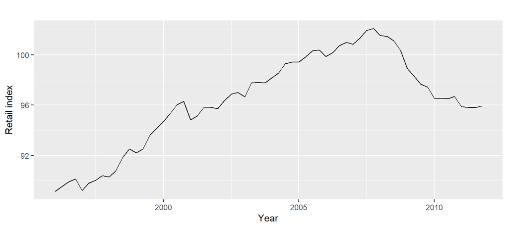

# Step 1: Data Visualization

- Quarterly retail trade index in the Euro area (17 countries), 1996-2011.

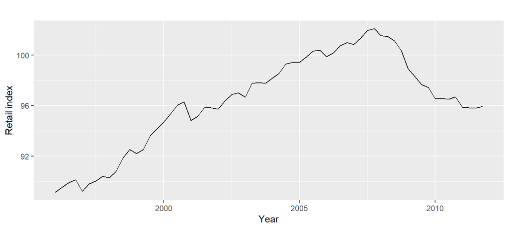

```r
library(fpp2)
autoplot(euretail) +
  xlab("Year") + ylab("Retail index")
```

# Step 1: Data Visualization (cont’d)

- Time series decomposition

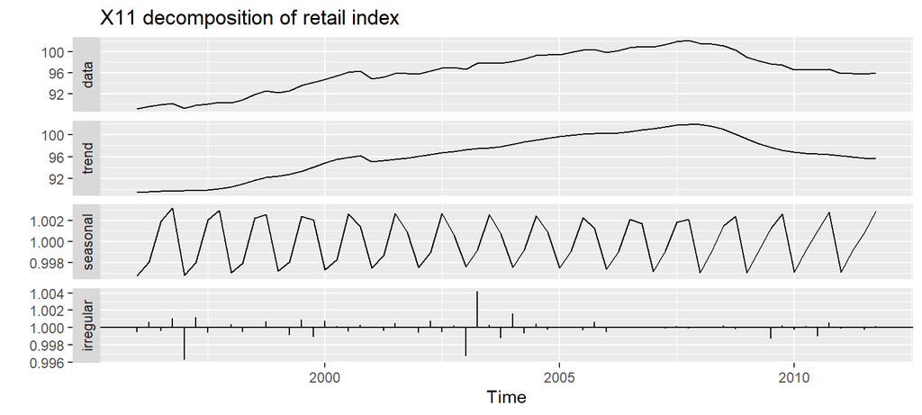

```r
library(seasonal)
fit <- seas(euretail, x11="")
autoplot(fit) +
  ggtitle("X11 decomposition of retail index")
```

- **Advantages**
  - Relatively robust to outliers
  - Completely automated choices for trend and seasonal changes
  - Very widely tested on economic data over a long period of time.
- **Disadvantages**
  - No prediction/confidence intervals
  - Ad hoc method with no underlying model
  - Only developed for quarterly and monthly data

# Step 2: Model Identification

- We use the Augmented Dickey-Fuller test (ADF) to determine its stationarity.
- The null hypothesis for the test is that the data is non-stationary.
- A p-value of ADF (0.99) is greater than 0.05. Hence, we fail to reject the null hypothesis for this test.

```r
library(fpp2)
library(tseries) # The `adf.test()` from the `tseries` package will do a Augmented Dickey-Fuller test
adf.test(euretail)
```

```
##
##  Augmented Dickey-Fuller Test
##
## data:  euretail
## Dickey-Fuller = -0.17892, Lag order = 3, p-value = 0.99
## alternative hypothesis: stationary
```

# Step 2: Model Identification (cont’d)

- **Taking the difference**
  - We take a difference of the time series data and check it with ADF again as follows.
  - A p-value of ADF (0.3058) is greater than 0.05. Hence, we fail to reject the null hypothesis for this test.

```r
library(tidyverse)
euretail%>% diff()  %>% adf.test()
```

```
##
##  Augmented Dickey-Fuller Test
##
## data:  .
## Dickey-Fuller = -2.6645, Lag order = 3, p-value = 0.3058
## alternative hypothesis: stationary
```

# Step 2: Model Identification (cont’d)

- Both seasonal and first differences are applied:
- A p-value of ADF (0.01) is less than 0.05. Therefore, we reject the null hypothesis and conclude that the data is **stationary**.

```r
library(tidyverse)
euretail %>% diff(lag=4) %>% diff() %>% adf.test()
```

```
##
##  Augmented Dickey-Fuller Test
##
## data:  .
## Dickey-Fuller = -5.5772, Lag order = 3, p-value = 0.01
## alternative hypothesis: stationary
```

# Step 2: Model Identification (cont’d)

- We begin with an ARIMA(0,1,1)(0,1,1) $_{4}$ (a first and seasonal difference, and non-seasonal and seasonal MA(1) components):
- The significant spike at lag 1 in the ACF suggests a non-seasonal MA(1) component.
- The significant spike at lag 4 in the ACF suggests a seasonal MA(1) component.

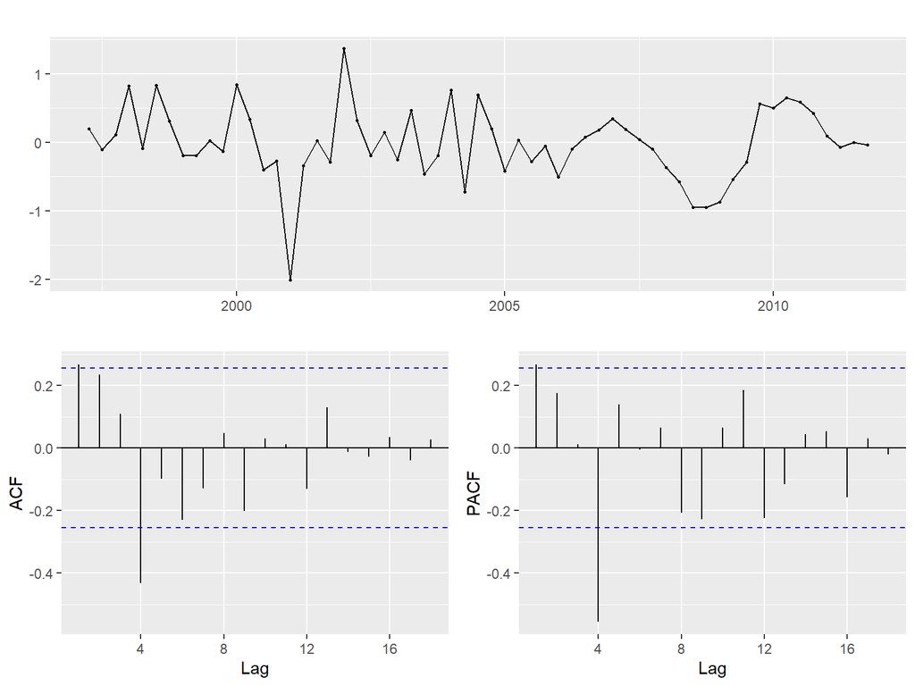

```r
# ACF and PACF
euretail %>% diff(lag=4) %>% diff() %>%
  ggtsdisplay()
```

- By analogous logic applied to the PACF, we could also have started with an ARIMA(1,1,0)(1,1,0) $_{4}$.

# Step 2: Model Selection Criteria

- ARIMA(0,1,1)(0,1,1) $_{4}$

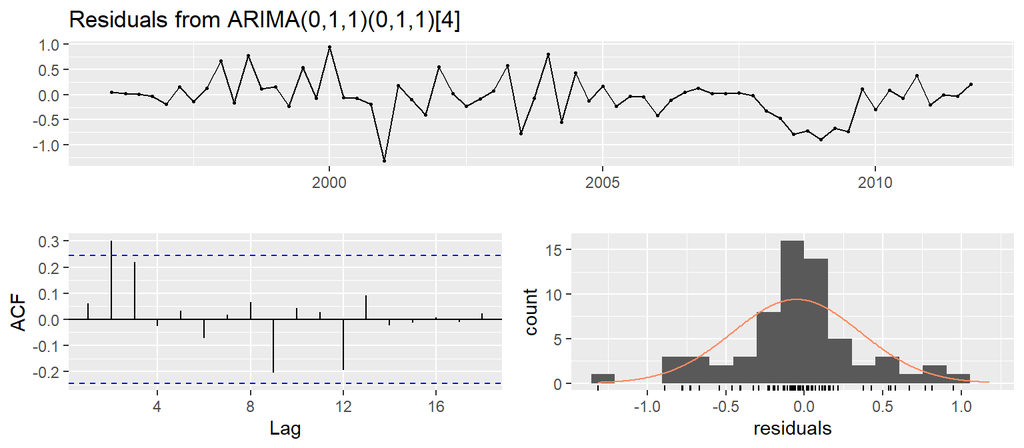

```
##
##  Ljung-Box test
##
## data:  Residuals from ARIMA(0,1,1)(0,1,1)[4]
## Q* = 10.654, df = 6, p-value = 0.09968
##
## Model df: 2.   Total lags used: 8
```

```r
fit <- Arima(euretail, order=c(0,1,1),
  seasonal=c(0,1,1))
checkresiduals(fit)
```

- ACF and PACF of residuals show significant spikes at $\color{blue}{\text{lag 2}}$, and maybe $\color{blue}{\text{lag 3}}$.
- Some additional non-seasonal terms need to be included in the model.
- ARIMA(0,1, $\color{blue}{\text{3}}$ )(0,1,1) $_{4}$ and ARIMA(0,1, $\color{blue}{\text{2}}$ )(0,1,1) $_{4}$.

# Step 2: Model Selection Criteria (cont’d)

- **Bayesian information criterion (BIC)**
- ARIMA(0,1, $\color{blue}{\text{3}}$ )(0,1,1) $_{4}$
- BIC of ARIMA(0,1, $\color{blue}{\text{3}}$ )(0,1,1) $_{4}$ model is 77.64592.

```r
(fit <- Arima(euretail, order=c(0,1,3),seasonal=c(0,1,1)))
```

```
## Series: euretail
## ARIMA(0,1,3)(0,1,1)[4]
##
## Coefficients:
##          ma1     ma2     ma3     sma1
##       0.2630  0.3694  0.4200  -0.6636
## s.e.  0.1237  0.1255  0.1294   0.1545
##
## sigma^2 estimated as 0.156:  log likelihood=-28.63
## AIC=67.26   AICc=68.39   BIC=77.65
```

```r
BIC(fit)
```

```
## [1] 77.64592
```

# Step 2: Model Selection Criteria (cont’d)

- ARIMA(0,1, $\color{blue}{\text{2}}$ )(0,1,1) $_{4}$
- BIC of ARIMA(0,1, $\color{blue}{\text{2}}$ )(0,1,1) $_{4}$ model is 81.83933.

```r
(fit2 <- Arima(euretail, order=c(0,1,2),seasonal=c(0,1,1)))
```

```
## Series: euretail
## ARIMA(0,1,2)(0,1,1)[4]
##
## Coefficients:
##          ma1     ma2     sma1
##       0.2303  0.2502  -0.6991
## s.e.  0.1484  0.1188   0.1284
##
## sigma^2 estimated as 0.1789:  log likelihood=-32.76
## AIC=73.53   AICc=74.27   BIC=81.84
```

```r
BIC(fit2)
```

```
## [1] 81.83933
```

- Based on the BIC, we exclude the ARIMA(0,1, $\color{blue}{\text{2}}$ )(0,1,1) $_{4}$.

# Step 3: Parameter Estimation

- Our model should have all the parameters are significant.
- ARIMA(0,1, $\color{blue}{\text{3}}$ )(0,1,1) $_{4}$

```r
### Parameter estimation
library(lmtest)
coeftest(fit)
```

```
##
## z test of coefficients:
##
##      Estimate Std. Error z value  Pr(>|z|)
## ma1   0.26302    0.12365  2.1270  0.033416 *
## ma2   0.36941    0.12554  2.9427  0.003254 **
## ma3   0.42002    0.12940  3.2458  0.001171 **
## sma1 -0.66357    0.15453 -4.2941 1.754e-05 ***
## ---
## Signif. codes:  0 '***' 0.001 '**' 0.01 '*' 0.05 '.' 0.1 ' ' 1
```

- Hence, we select our final forecasting model: ARIMA(0,1, $\color{blue}{\text{3}}$ )(0,1,1) $_{4}$.

# Step 4: Diagnostic Check

- ARIMA(0,1, $\color{blue}{\text{3}}$ )(0,1,1) $_{4}$
- We further look at the residuals. The residual plots below look fine.

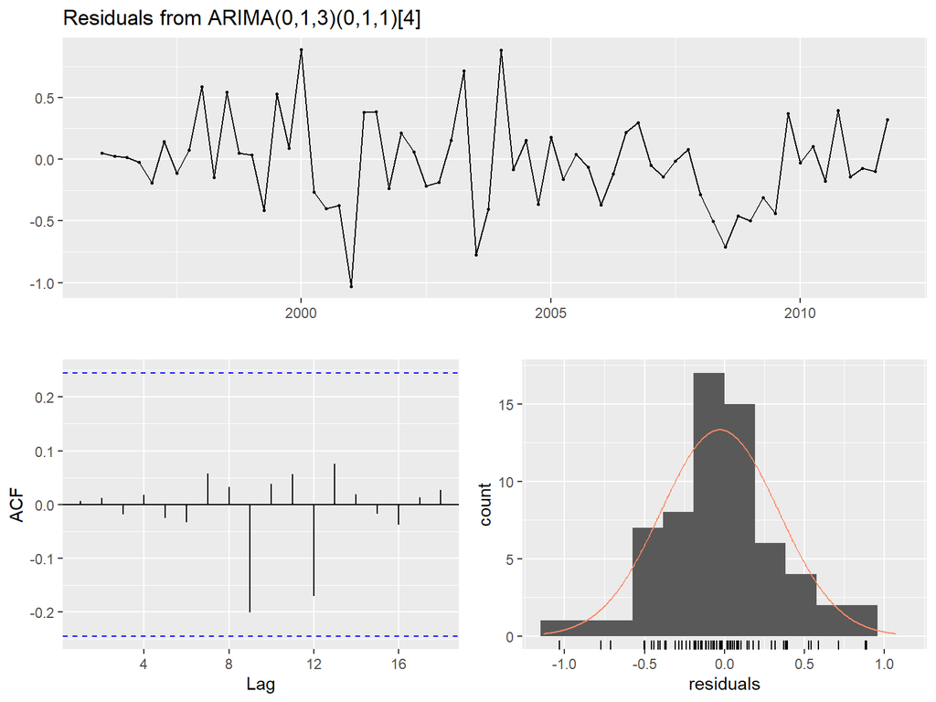

```
##
##  Ljung-Box test
##
## data:  Residuals from ARIMA(0,1,3)(0,1,1)[4]
## Q* = 0.51128, df = 4, p-value = 0.9724
##
## Model df: 4.   Total lags used: 8
```

```r
fit <- Arima(euretail, order=c(0,1,3),
  seasonal=c(0,1,1))
checkresiduals(fit)
```

# Step 4: Diagnostic Check (cont’d)

- We use Ljung-Box test:

```r
Box.test(resid(fit), lag = 10, type = "Ljung-Box")
```

```
##
##  Box-Ljung test
##
## data:  resid(fit)
## X-squared = 3.7311, df = 10, p-value = 0.9587
```

which fails to reject the null hypothesis.

- We fail to reject the null hypothesis $H_{0}$. Thus, we can conclude that the residuals are **NOT** distinguishable from a white noise series.
- **Note**: Ljung-Box test
  - In general, the Ljung-Box test (a test of autocorrelation of the residuals) is defined as:
    - $H_{0}$ (null hypothesis): the autocorrelations come from a white noise series.
    - $H_{a}$ (alternative hypothesis): the autocorrelations do not come from a white noise series.

# Step 4: Diagnostic Check (cont’d)

```r
coeftest(fit)
```

```
##
## z test of coefficients:
##
##      Estimate Std. Error z value  Pr(>|z|)
## ma1   0.26302    0.12365  2.1270  0.033416 *
## ma2   0.36941    0.12554  2.9427  0.003254 **
## ma3   0.42002    0.12940  3.2458  0.001171 **
## sma1 -0.66357    0.15453 -4.2941 1.754e-05 ***
## ---
## Signif. codes:  0 '***' 0.001 '**' 0.01 '*' 0.05 '.' 0.1 ' ' 1
```

- Hence, our final model is the ARIMA(0,1,3)(0,1,1)[4]:$(1-B^4)(1-B)y_t$=0.26 $\varepsilon_{t-1}+0.37\varepsilon_{t-2}+0.42\varepsilon_{t-3}-0.67 \varepsilon_{t-4}+\varepsilon_{t}$, where $\varepsilon_t\sim(0, \sigma^2)$.
- Note:
  - Autoregressive Moving Average models **(ARMA)**:
    - $y_{t}=c+\phi_{1}y_{t-1}+\cdots+\phi_{p}y_{t-p}+\theta_{1}\varepsilon_{t-1}+\cdots+\theta_{q}\varepsilon_{t -q}+\varepsilon_{t}$, where $\varepsilon_t$ is white noise.
  - Autoregressive Integrated Moving Average models **(ARIMA)**:
    - Combine ARMA model with **differencing**.
    - $(1-B)^d y_t$ follows an ARMA model.
    - A first difference can be written as $y'_{t} = y_{t} - y_{t-1} = y_t - By_{t} = (1 - B)y_{t}$.

# Step 5: Forecasts for the Next Two Years(8 observations)

- Lastly, we make a forecast for next two years with 80$\%$ and 95$\%$ prediction intervals, respectively, as follows:

```r
library(forecast)
fit%>% forecast(h = 8,level=c(80,95))
```

```
##         Point Forecast    Lo 80    Hi 80    Lo 95    Hi 95
## 2012 Q1       95.17620 94.67006 95.68233 94.40214 95.95026
## 2012 Q2       95.23809 94.42273 96.05345 93.99111 96.48507
## 2012 Q3       95.32444 94.16364 96.48523 93.54915 97.09972
## 2012 Q4       95.33633 93.77859 96.89408 92.95397 97.71870
## 2013 Q1       94.56087 92.58895 96.53279 91.54508 97.57666
## 2013 Q2       94.57178 92.23497 96.90859 90.99794 98.14562
## 2013 Q3       94.56911 91.88684 97.25138 90.46694 98.67129
## 2013 Q4       94.58101 91.56075 97.60126 89.96193 99.20009
```

# Step 5: Forecasts for the Next Two Years(8 observations) (cont’d)

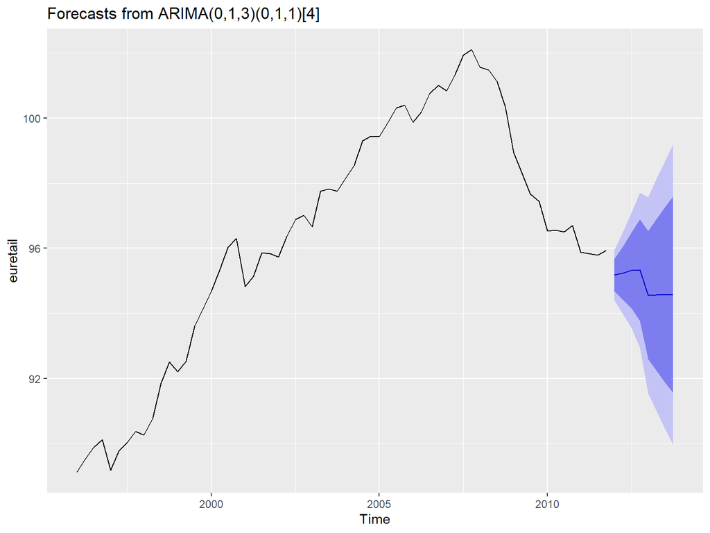

```r
library(forecast)
fit%>% forecast(h = 8,level=c(80,95))%>%autoplot()
```

# What if we use automatic modelling procedure in R?

```r
auto.arima(euretail)
```

```
## Series: euretail
## ARIMA(0,1,3)(0,1,1)[4]
##
## Coefficients:
##          ma1     ma2     ma3     sma1
##       0.2630  0.3694  0.4200  -0.6636
## s.e.  0.1237  0.1255  0.1294   0.1545
##
## sigma^2 estimated as 0.156:  log likelihood=-28.63
## AIC=67.26   AICc=68.39   BIC=77.65
```

# What if we use automatic modelling procedure in R? (cont’d)

```r
auto.arima(euretail, stepwise=FALSE, approximation=FALSE)
```

```
## Series: euretail
## ARIMA(0,1,3)(0,1,1)[4]
##
## Coefficients:
##          ma1     ma2     ma3     sma1
##       0.2630  0.3694  0.4200  -0.6636
## s.e.  0.1237  0.1255  0.1294   0.1545
##
## sigma^2 estimated as 0.156:  log likelihood=-28.63
## AIC=67.26   AICc=68.39   BIC=77.65
```

# Backup

- **The autocorrelation function (ACF) measures the linear relationship between lagged values of a time series**.
  - Visualizes how much the most recent value of the series is correlated with past values of the series (lags).
  - If the data has $\color{blue}{\text{a trend}}$, then the autocorrelations for small lags tend to be positive and large because observations nearby in time are also nearby in size.
  - If the data are $\color{blue}{\text{seasonal}}$, then the autocorrelations will be larger for seasonal lags at multiples of seasonal frequency than other lags.
- **The partial autocorrelation function (PACF) measures the linear relationship between the correlations of the residuals** .
  - Visualizes whether certain lags are good for modeling or not; useful for data with a seasonal pattern.
  - Removes dependence of lags on other lags by using the correlations of the residuals.